# Data Visualisation

The grammar of graphics with `{ggplot2}`

**EPFL Extension School**

## Visualise: explore and communicate

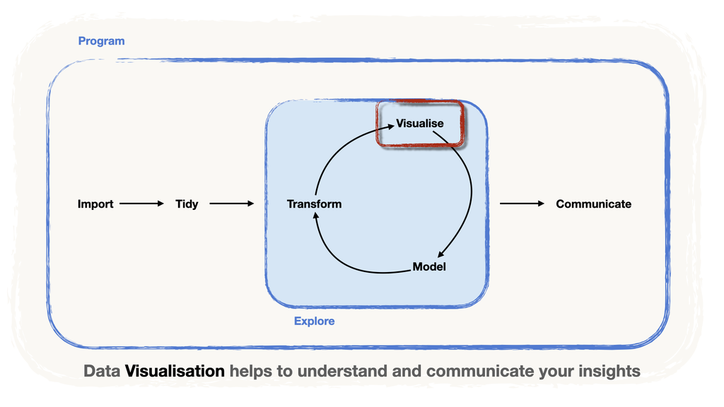

- Part of the **exploration** loop
- A **tool to communicate** results clearly

Today: the **grammar of graphics**, with `{ggplot2}`.

# A Grammar for Data Visualisation

## The grammar of graphics

- **Rules** to build graphics, like the grammar of a language ([Wilkinson, 2005](https://link.springer.com/book/10.1007/0-387-28695-0))

| Language | Graphics |
| --- | --- |
| nouns | **data** |
| adjectives | **aesthetics** |
| verbs | **geometries** |
| adverbs | **themes** |

## Data

The **dataset** with the **variables to plot**. Our example: **Variable 1**, **Variable 2** and **Group** (A, B or C).

| Group | Variable 1 | Variable 2 |
| --- | --- | --- |
| A | 2.88 | 12.53 |
| A | 7.88 | 31.41 |
| A | 4.09 | 16.19 |
| A | 8.83 | 40.79 |
| A | 9.40 | 36.70 |
| A | 0.46 | 7.91 |

## Aesthetics and aesthetic mappings

- **Aesthetics**: the features of the graphic that can depend on the data: `x`, `y`, `color`, `fill`, `size`…
- **Aesthetic mapping**: which **variable** goes to which **aesthetic**

Here: two numeric variables on the axes, the categorical one on the colour:

- `x = Variable 1`
- `y = Variable 2`
- `color = Group`

## Geometries and themes

- **Geometry**: the **type of plot**: `point`, `line`, `area`, `col`umn, `bar`…
  - Here, a scatterplot: `geom_point()`
  - It depends on the **question** and on the **nature of the variables**
- **Theme**: all the purely cosmetic “ink”: titles, axes…

## Putting it together

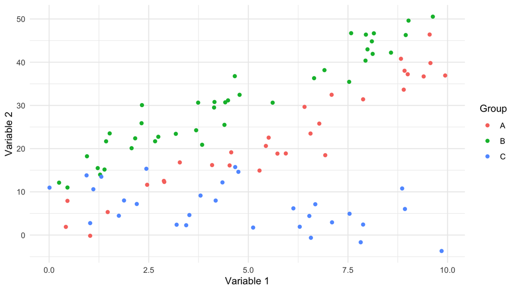

- A clear **linear link** between Variable 1 and Variable 2…
- …but it **differs across the groups**

# `{ggplot2}` syntax

## `{ggplot2}`: the grammar of graphics in R

**Note**

It’s even in the name! The ‘gg’ stands for… **g**rammar of **g**raphics.

Our data: women’s Grand Slam singles matches, 1968–2021. We keep the **finals**.

```r
library(readr)
library(dplyr)

wta <-
  "../data/wta_grand_slam_data.csv" %>%
  read_csv()

finals <- wta %>%
  filter(round == "F")

head(finals)
```

```
# A tibble: 6 × 45
   year tourney_id     tourney_name surface tourney_level tourney_date match_num
  <dbl> <chr>          <chr>        <chr>   <chr>                <dbl>     <dbl>
1  1968 1968-W-SL-AUS… Australian … Grass   G                 19680119        61
2  1968 1968-W-SL-FRA… Roland Garr… Clay    G                 19680527        95
3  1968 1968-W-SL-GBR… Wimbledon    Grass   G                 19680624        95
4  1968 1968-W-SL-USA… US Open      Grass   G                 19680829        63
5  1969 1969-W-SL-AUS… Australian … Grass   G                 19690120        31
6  1969 1969-W-SL-FRA… Roland Garr… Clay    G                 19690526        63
```

```r
library(ggplot2)
```

## Plots are built in layers

**Important**

1. A **base plot**: the **data** and the **aesthetic mappings**
2. **+** the **geometries**
3. **+** the cosmetic elements and other layers

## Scatterplots with `geom_point()`

> *Is there a **trend in the age** of the tournament winners over the **years**?*
- The base layer: `ggplot()`, with the `data` and the mapping `aes(x = year, y = winner_age)`

**Important**

To define the **aesthetic mapping**, we rely on the function `aes(...)`.

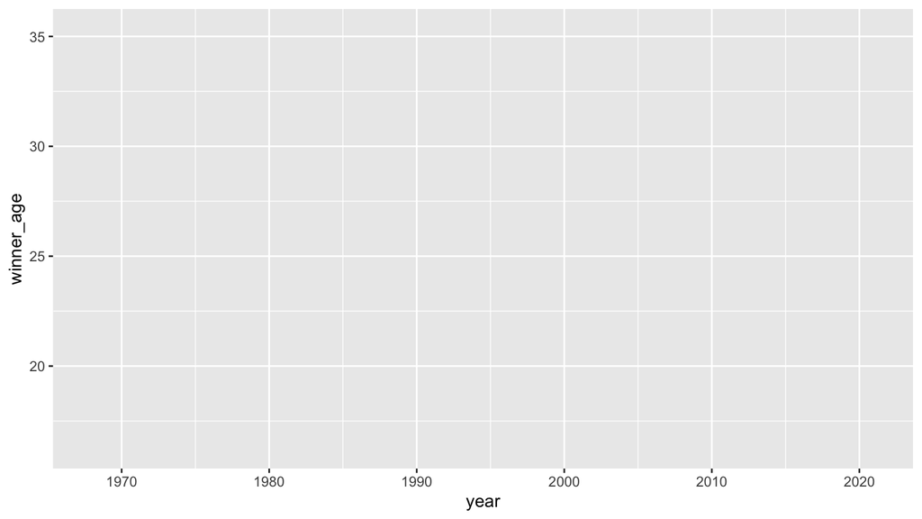

```r
# create a base plot

ggplot(data = finals, # the data
       mapping = aes(x = year, # mapping the x-axis to year
                     y = winner_age) # mapping the y-axis to winner age
       )
```

> Nothing yet! The geometry is missing! But what geometry should we add?

## Adding a geometry with `+`

- One **point** per observation: `geom_point()`, **added** to the base layer with `+`

**Warning**

In `{ggplot2}` we use the `+` instead of the `%>%` sign to add layers!

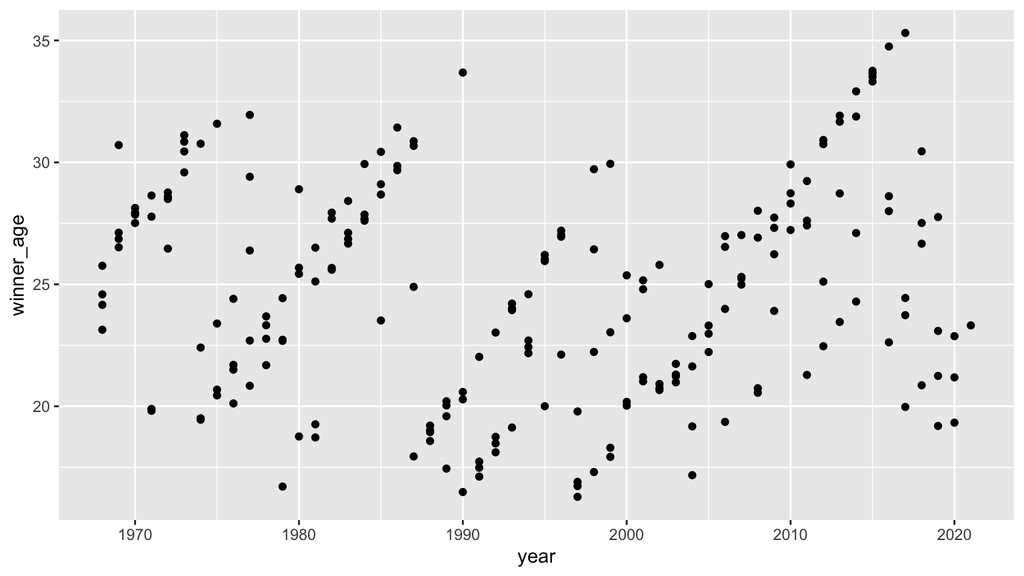

```r
ggplot(data = finals,
       mapping = aes(x = year,
                     y = winner_age)) +
  geom_point() # our geometry of choice: points
```

- **No uniform trend**, but **clusters** of aligned points

## Mapping a third variable to `color`

> *Could there be trends within groups?* Let’s colour by `surface`: Clay, Grass or Hard.

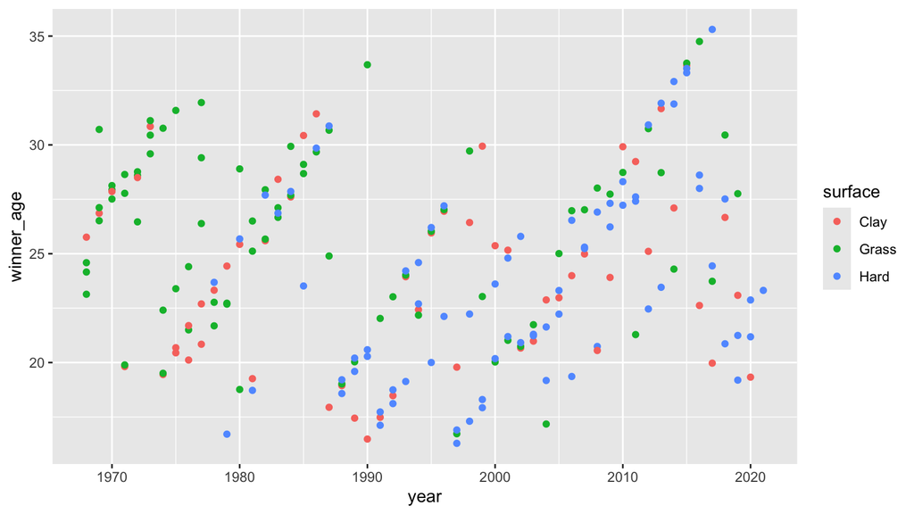

```r
ggplot(data = finals,
       mapping = aes(x = year,
                     y = winner_age,
                     color = surface)) + # mapping surface to color
  geom_point()
```

Colours… but **still no uniform trend**.

## One colour per player

> Are the clusters the **same player** winning over the years, and **getting older**?

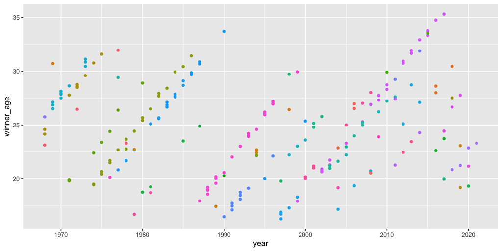

```r
ggplot(data = finals,
       mapping = aes(x = year,
                     y = winner_age,
                     color = winner_name)) + #mapping winner name to color
  geom_point() +
  theme(legend.position = "none") # 54 players: too many for a readable legend
```

> Voilà! Most **points with the same color align**, indicating the source of the clusters.

## What we learnt from the colours

**Note**

Often, mapping a third variable to an aesthetic such as color can help us discover trends within **groups**.

**Look at the chunk option!**

We have defined a dimension of the chart in the chunk options (`fig.width=10, fig.height= 5`) because we want to **enlarge the plot**.

We have also **hidden the legend**: with 54 different players, nobody could match 54 colours to their names. Here, we only need to see that points of the same colour line up.

**The surface plot wasn’t useless**

You can see that **before 1977** there are fewer blue points: tournaments were played only on *grass* or *clay*, and *hard* surfaces arrived only after that year.

## Boxplots with `geom_boxplot()`

> *Is there a difference in the distribution of the tournament winners’ age across the different surfaces?*
- A new question, a new geometry: **boxplots** summarise **distributions**
- First, the base plot, with `surface` on the `x` axis

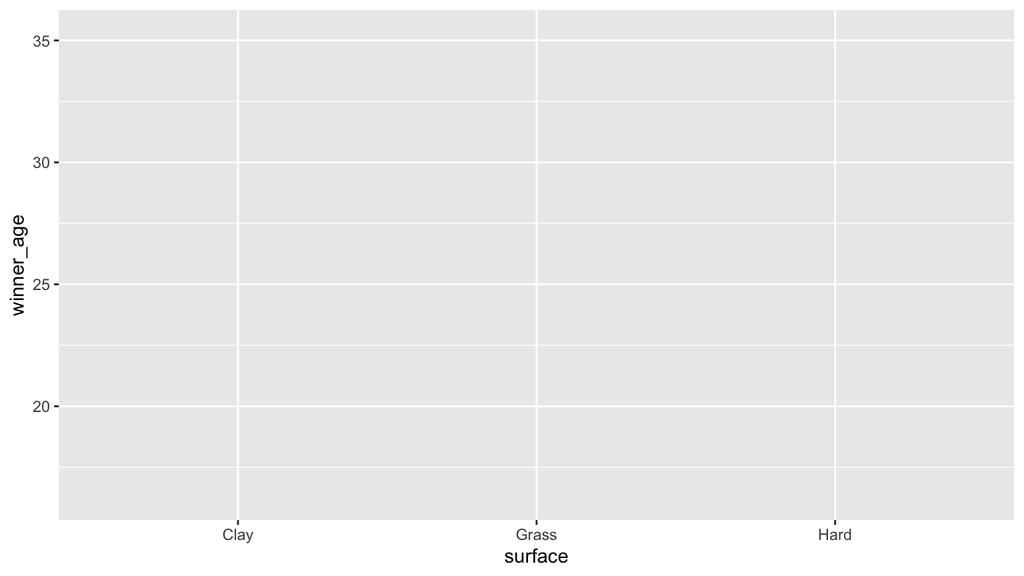

```r
ggplot(data = finals,
       mapping = aes(x = surface, # we change the mapping of the x axis
                     y = winner_age))
```

## Adding `geom_boxplot()`

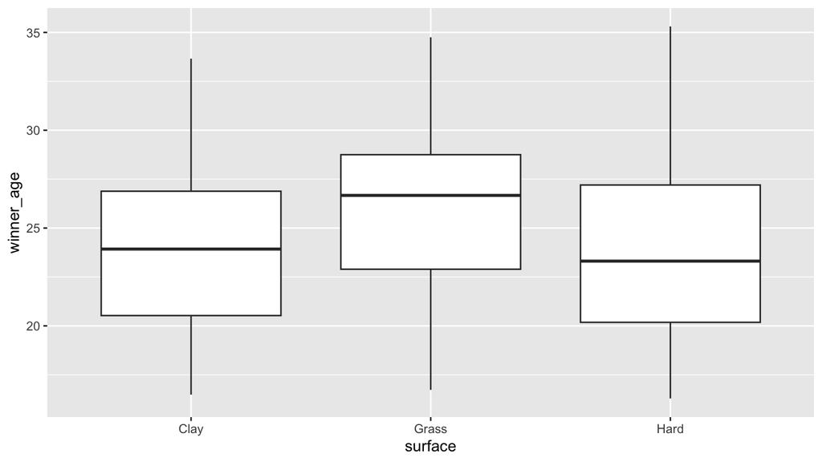

```r
ggplot(data = finals,
       mapping = aes(x = surface,
                     y = winner_age)) +
  geom_boxplot() # adding the geometry to create the boxplot
```

**Where do the boxes come from?**

The summary statistics needed to draw the boxplots (i.e. the median, the upper and lower quartiles) are computed from the “raw” data when drawing the plot.

**Grass** favours **older** winners, **hard** surfaces **younger** ones.

## Exploring is not confirming

**Exploratory Data Analysis**

- Plots like these **explore** the links between variables
- To **confirm** them, more work is needed, e.g. a **statistical test**

# Adding more geometries `geoms_*`

## Layers on layers

> *How many observations per surface? Any extreme values?* Let’s add **points** on top of the boxplots.

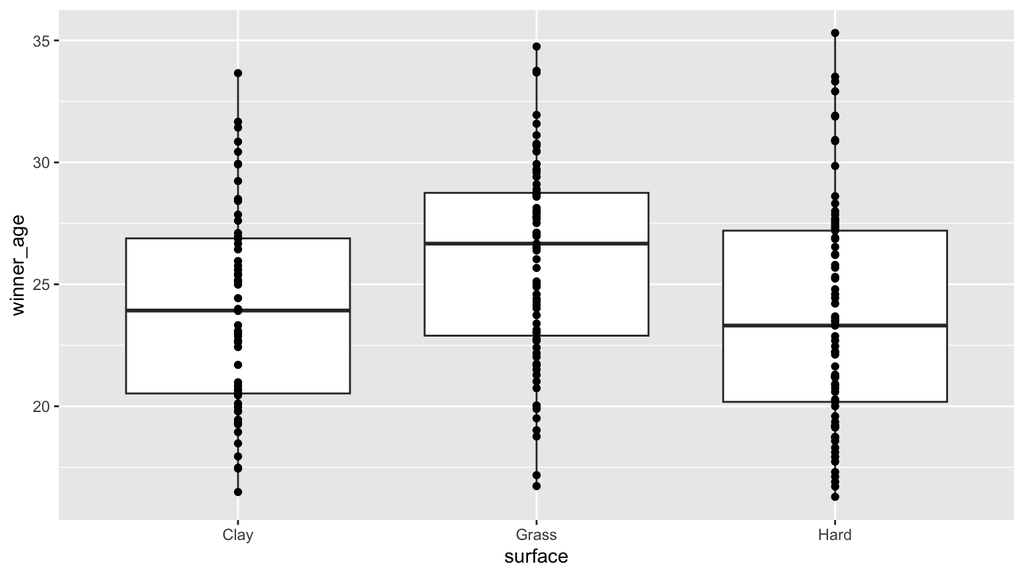

```r
ggplot(data = finals,
       mapping = aes(x = surface,
                     y = winner_age)) +
  geom_boxplot() +
  geom_point() # added a new geometry representation for the same mappings
```

**Careful with Overplotting!**

**Overplotting**: many points drawn **on top of each other**. Common with points over a categorical variable.

## `geom_jitter()`: shake the points

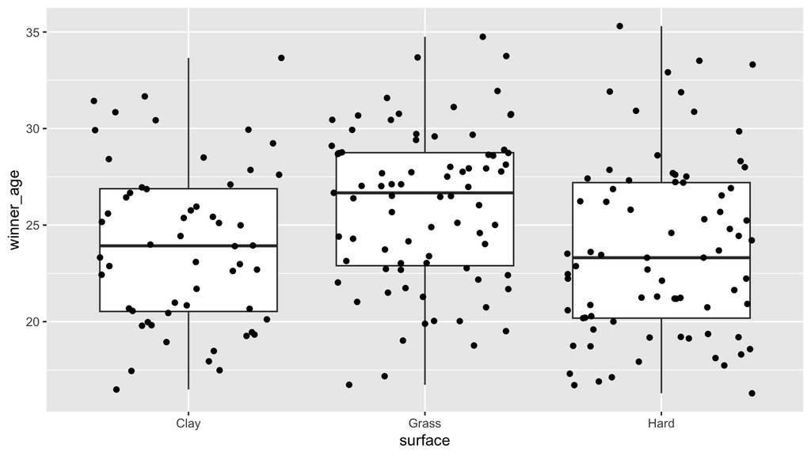

```r
ggplot(data = finals,
       mapping = aes(x = surface,
                     y = winner_age)) +
  geom_boxplot() +
  geom_jitter() # added a jitter on top
```

## Every layer has arguments

`width` sets how far the points spread

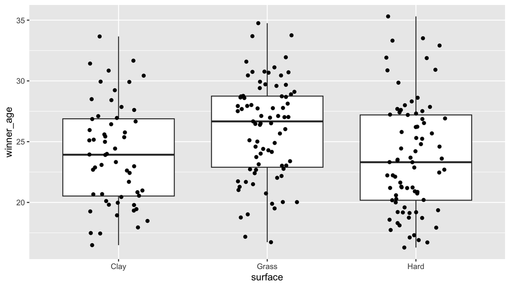

```r
ggplot(data = finals,
       mapping = aes(x = surface,
                     y = winner_age)) +
  geom_boxplot() +
  geom_jitter(width = 0.2) # spreading the points a little less
```

**Every layer has Arguments**

Every layer is a function, hence it has arguments!

# Case study: Customising a bar chart

## Who won the most Grand Slam titles?

**Note**

Let’s use our **Data Wrangling** skills!

```r
total_wins <- finals %>%
  group_by(winner_name) %>%
  summarise(total_wins = n(), .groups = "drop") %>%
  arrange(desc(total_wins))
```

```r
slice_head(total_wins, n = 6)
```

```
# A tibble: 6 × 2
  winner_name         total_wins
  <chr>                    <int>
1 Serena Williams             23
2 Steffi Graf                 22
3 Chris Evert                 18
4 Martina Navratilova         18
5 Margaret Court              11
6 Billie Jean King             9
```

## A first bar chart with `geom_col()`

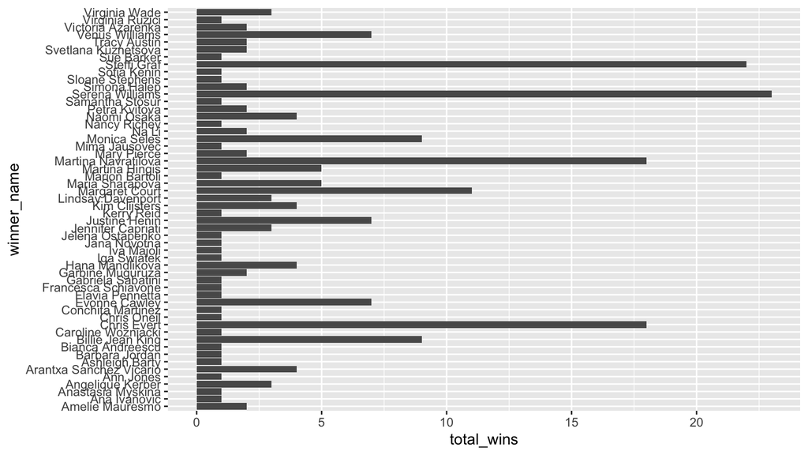

```r
ggplot(data = total_wins,
       mapping = aes(x = total_wins,
                     y = winner_name)) +
  geom_col()
```

Time to give it a bit more flair!

## Ordering the bars

- Bars are in **alphabetical** order: `winner_name` is still `character`
- `ggplot()` ignores our `arrange()`!

**Important**

Turn `winner_name` into a `factor`: a type **with an order**. In the `{tidyverse}`: the package `{forcats}`.

```r
library(forcats)

total_wins <- total_wins %>%
  # we reorder the winner_name by total wins
  mutate(winner_name = fct_reorder(winner_name, total_wins))
```

`winner_name` is now a factor (`fct`):

```r
slice_head(total_wins, n = 6)
```

```
# A tibble: 6 × 2
  winner_name         total_wins
  <fct>                    <int>
1 Serena Williams             23
2 Steffi Graf                 22
3 Chris Evert                 18
4 Martina Navratilova         18
5 Margaret Court              11
6 Billie Jean King             9
```

## Ordered bars

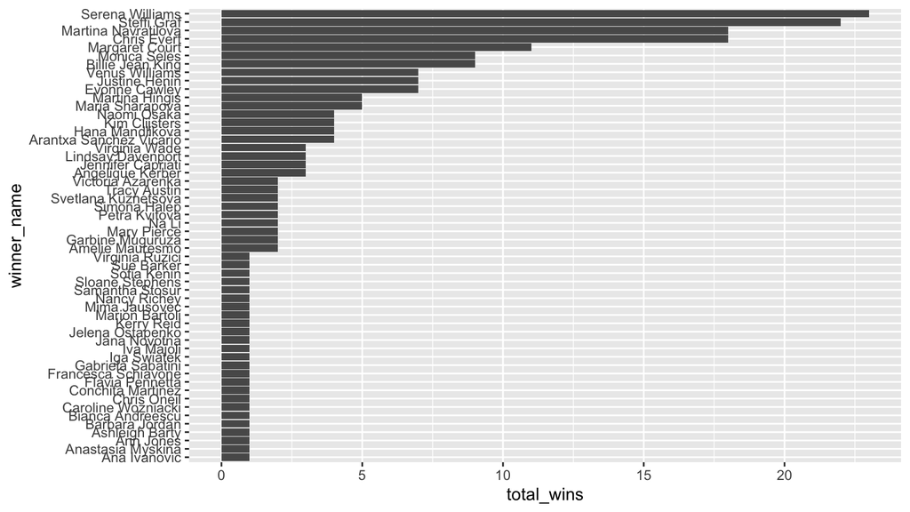

```r
ggplot(data = total_wins,
       mapping = aes(x = total_wins,
                     y = winner_name)) +
  geom_col()
```

> The plot is already much more readable! …but how can we improve it?

## Focusing our message

- Keep the **top 20** with `slice_max()`, fed directly to `ggplot()`
- The original tibble stays unchanged

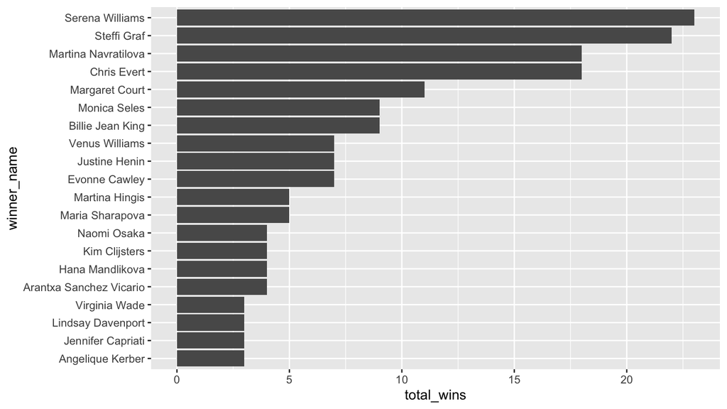

```r
total_wins %>%
  slice_max(order_by = total_wins, n = 20) %>%
  ggplot(mapping = aes(x = total_wins,
                       y = winner_name)) +
  geom_col()
```

> Much better, the plot almost speaks for itself. But let’s fix those axes.

## Cosmetic time!

- A title and axis names, with a `labs()` layer

**Note**

The `labs()` layer is part of the layers that help with the *cosmetic* aspects of the plot.

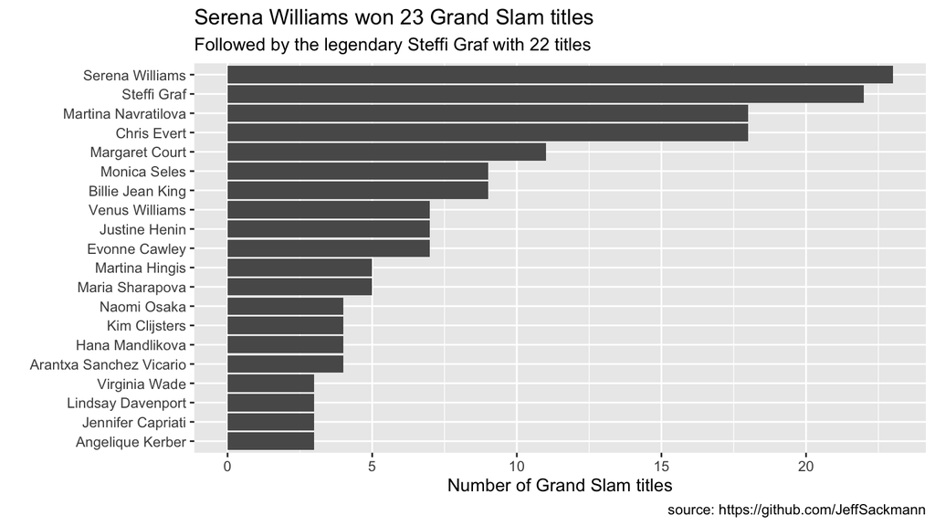

```r
total_wins %>%
  slice_max(order_by = total_wins, n = 20) %>%
  ggplot(mapping = aes(x = total_wins,
                       y = winner_name)) +
  geom_col() +
  #adding labels
  labs(title = "Serena Williams won 23 Grand Slam titles",
       subtitle =  "Followed by the legendary Steffi Graf with 22 titles",
       x = "Number of Grand Slam titles",
       y = "",
       caption = "source: https://github.com/JeffSackmann")
```

## Ready-made themes

**Note**

`{ggplot2}` has multiple ready-to-use themes. You can see a list of them [here](https://ggplot2.tidyverse.org/reference/ggtheme.html). Some of them are:

- `theme_minimal()`: a good starting point
- `theme_dark()`: if [you want it darker](https://youtu.be/v0nmHymgM7Y)
- `theme_bw()`: to see things in black and white
- `theme_classic()`

You can see the proposals if you type `theme_` in your console.

## Let’s go `minimal`

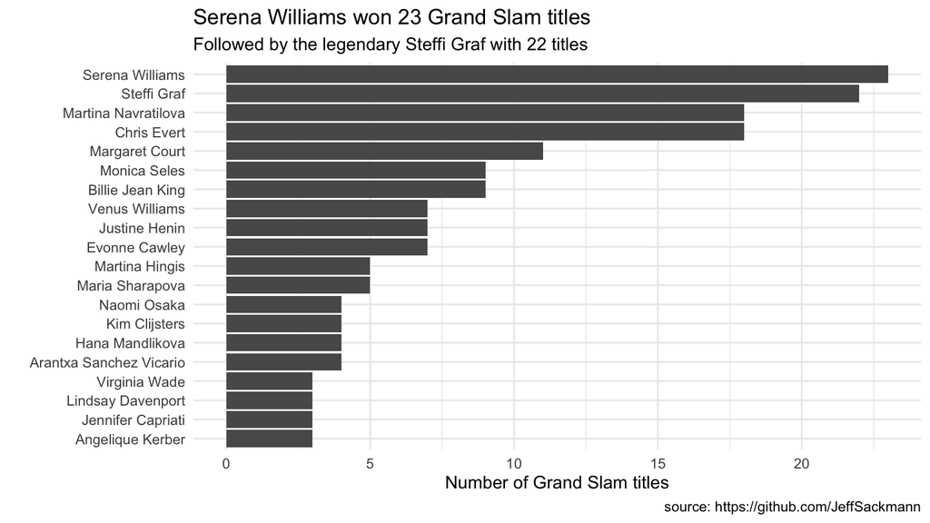

```r
total_wins %>%
  slice_max(order_by = total_wins, n = 20) %>%
  ggplot(mapping = aes(x = total_wins,
                       y = winner_name)) +
  geom_col() +
  labs(title = "Serena Williams won 23 Grand Slam titles",
       subtitle =  "Followed by the legendary Steffi Graf with 22 titles",
       x = "Number of Grand Slam titles",
       y = "",
       caption = "source: https://github.com/JeffSackmann") +
  # adding a theme
  theme_minimal()
```

## How about some color?

Let’s try `fill = "lightblue"`…

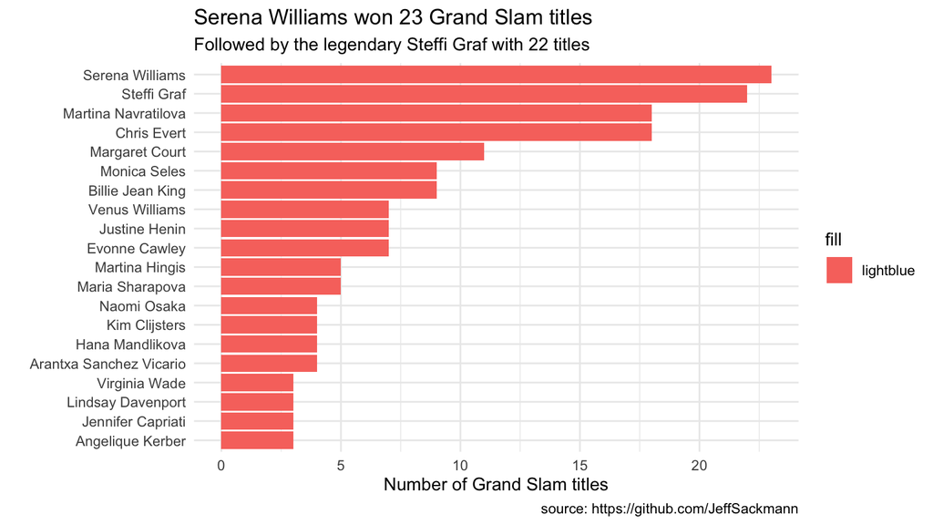

```r
total_wins %>%
  slice_max(order_by = total_wins, n = 20) %>%
  ggplot(mapping = aes(x = total_wins,
                       y = winner_name,
                       fill = "lightblue")) +
  geom_col() +
  labs(title = "Serena Williams won 23 Grand Slam titles",
       subtitle =  "Followed by the legendary Steffi Graf with 22 titles",
       x = "Number of Grand Slam titles",
       y = "",
       caption = "source: https://github.com/JeffSackmann") +
  theme_minimal()
```

> Oh no! Something is wrong… Can you guess what?

## What’s going on?

**What’s going on?**

- When we place `fill = "lightblue"` in the call to `aes()`, we are **mapping a variable** with the **single value** `"lightblue"` to the `fill` of the bars…
- …and not setting it as a **parameter!**
- `ggplot()` does not understand that `"lightblue"` is actually a color we want to set.
- A mapping would make sense if we wanted the color of the bars to depend on the number of `total_wins`.
- This creates a continuous color scale, applied to the color of the bars.

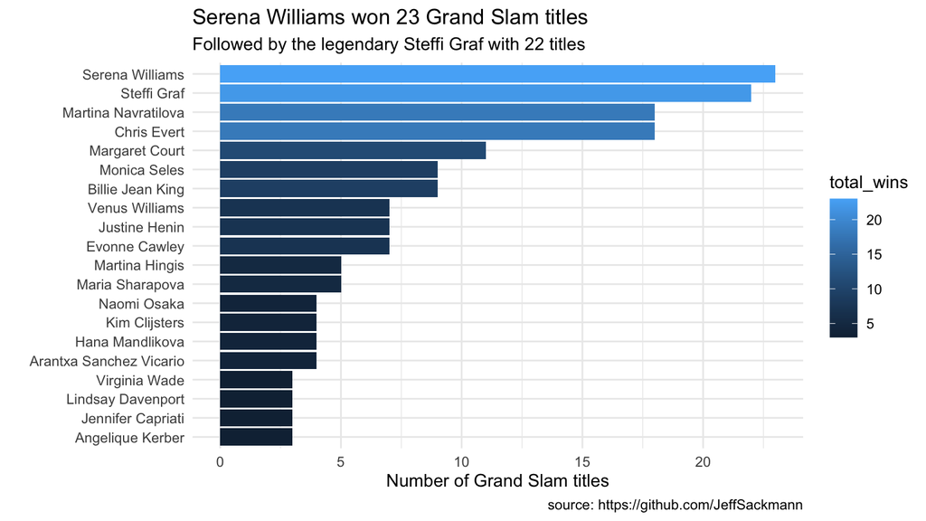

```r
total_wins %>%
  slice_max(order_by = total_wins, n = 20) %>%
  ggplot(mapping = aes(x = total_wins,
                       y = winner_name,
                       fill = total_wins)) +
  geom_col() +
  labs(title = "Serena Williams won 23 Grand Slam titles",
       subtitle =  "Followed by the legendary Steffi Graf with 22 titles",
       x = "Number of Grand Slam titles",
       y = "",
       caption = "source: https://github.com/JeffSackmann") +
  theme_minimal()
```

## Setting a colour: outside `aes()`

- To give **all** the bars one colour, set it **inside the `geom_*()`**, outside `aes()`

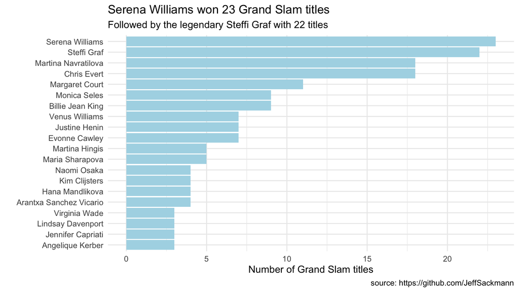

```r
total_wins %>%
  slice_max(order_by = total_wins, n = 20) %>%
  ggplot(mapping = aes(x = total_wins,
                       y = winner_name)) +
  geom_col(fill = "lightblue") + # setting a colour for all the bars
  labs(title = "Serena Williams won 23 Grand Slam titles",
       subtitle =  "Followed by the legendary Steffi Graf with 22 titles",
       x = "Number of Grand Slam titles",
       y = "",
       caption = "source: https://github.com/JeffSackmann") +
  theme_minimal()
```

# Case Study: Plotting more variables

## Did Serena win more than Steffi on all surfaces?

- Count the finals won **by player** and **by surface**, then map `surface` to `fill`
- But first, **reorder** the players again

**Other nifty `{forcats}` tricks**

- `fct_infreq()` orders factors by frequency: applied to `winner_name`, it orders the players without the need to count!
- `fct_rev()` reverses the order, to make it **descending**.

```r
total_wins_surface <- finals %>%
  mutate(winner_name = fct_rev(fct_infreq(winner_name))) %>% #reordering the winner names
  group_by(winner_name, surface) %>%
  summarise(total_wins = n(), .groups = "drop") %>%
  arrange(surface, desc(total_wins))
```

## The top 20, as a vector

`pull()` extracts the names of the top 20 into the vector `top20`

```r
top20 <- total_wins %>%
  slice_max(order_by = total_wins, n = 20) %>%
  pull(winner_name)

top20
```

```
 [1] Serena Williams         Steffi Graf             Chris Evert
 [4] Martina Navratilova     Margaret Court          Billie Jean King
 [7] Monica Seles            Evonne Cawley           Justine Henin
[10] Venus Williams          Maria Sharapova         Martina Hingis
[13] Arantxa Sanchez Vicario Hana Mandlikova         Kim Clijsters
[16] Naomi Osaka             Angelique Kerber        Jennifer Capriati
[19] Lindsay Davenport       Virginia Wade
54 Levels: Ana Ivanovic Anastasia Myskina Ann Jones ... Serena Williams
```

## Titles by surface

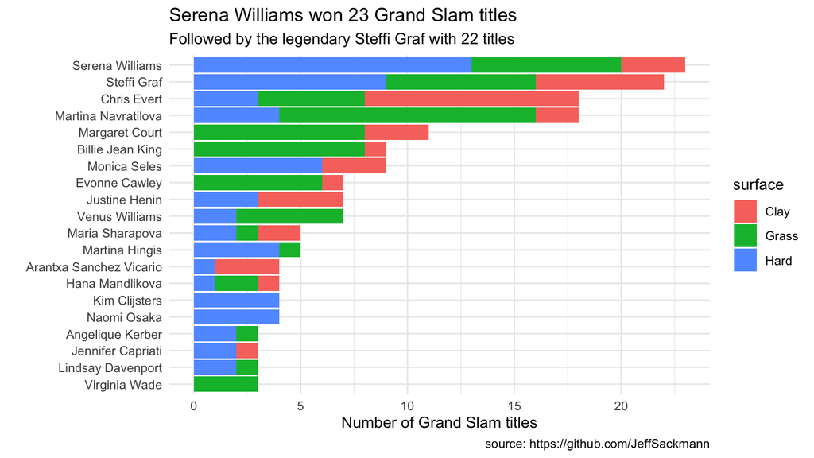

```r
total_wins_surface %>%
  filter(winner_name %in% top20) %>%
  ggplot(mapping = aes(x = total_wins,
                         y = winner_name,
                         fill = surface)) +
  geom_col() +
  labs(
    title = "Serena Williams won 23 Grand Slam titles",
    subtitle =  "Followed by the legendary Steffi Graf with 22 titles",
    x = "Number of Grand Slam titles",
    y = "",
    caption = "source: https://github.com/JeffSackmann"
  ) +
  theme_minimal()
```

- Steffi Graf won more on **clay**, Serena more on **hard** surfaces
- But **grass** is very hard to compare!

# Creating multiple mini-plots

## One mini-plot per surface: `facet_wrap()`

- Compare the players **surface by surface**
- Mini-plots are called **facets**: the faceting variable goes into `vars()`

**Important**

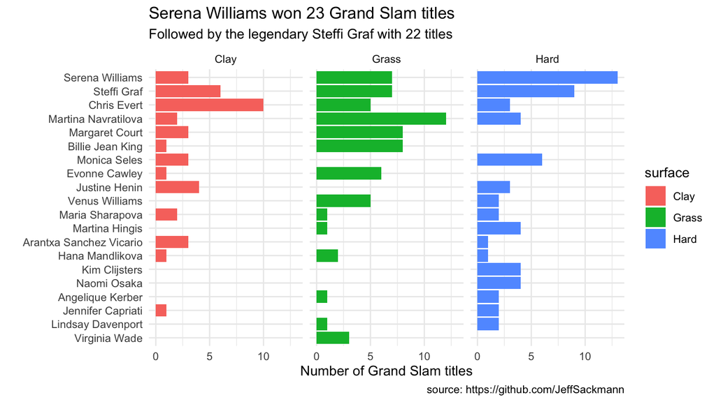

```r
total_wins_surface %>%
  filter(winner_name %in% top20) %>%
  ggplot(mapping = aes(x = total_wins,
                         y = winner_name,
                         fill = surface)) +
  geom_col() +
  labs(
    title = "Serena Williams won 23 Grand Slam titles",
    subtitle =  "Followed by the legendary Steffi Graf with 22 titles",
    x = "Number of Grand Slam titles",
    y = "",
    caption = "source: https://github.com/JeffSackmann"
  ) +
  theme_minimal() +
  facet_wrap(vars(surface)) # using surface as a faceting variable
```

## Hiding the redundant legend

**The colours are redundant too**

The colors here are a bit redundant as well, but we keep them just for personal taste; feel free to remove them.

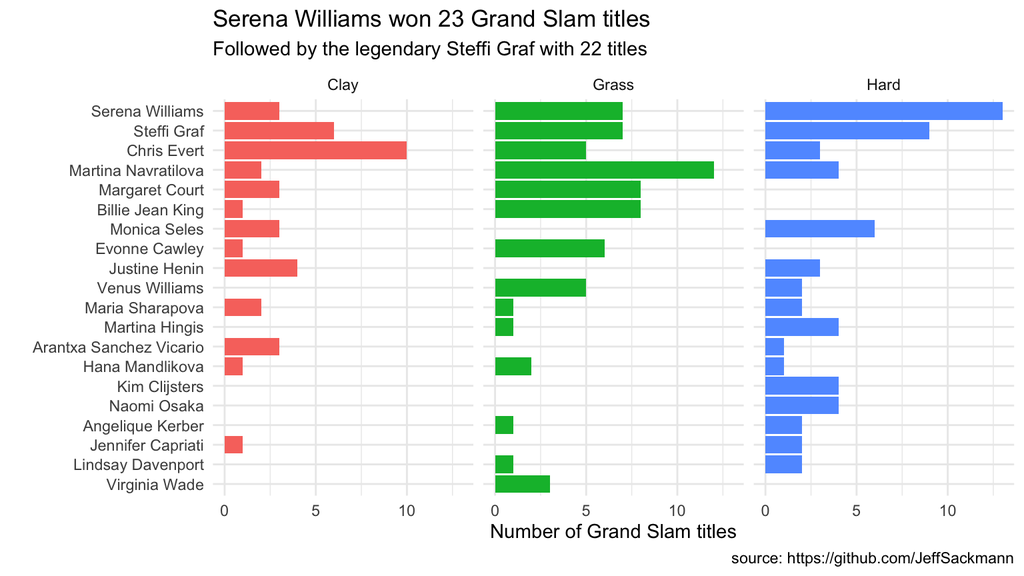

```r
total_wins_surface %>%
  filter(winner_name %in% top20) %>%
  ggplot(mapping = aes(x = total_wins,
                         y = winner_name,
                         fill = surface)) +
  geom_col() +
  labs(
    title = "Serena Williams won 23 Grand Slam titles",
    subtitle =  "Followed by the legendary Steffi Graf with 22 titles",
    x = "Number of Grand Slam titles",
    y = "",
    caption = "source: https://github.com/JeffSackmann"
  ) +
  theme_minimal() +
  facet_wrap(vars(surface)) +
  theme(legend.position = "none") #removing the legend
```

# Exporting your plots

## `ggsave()` saves the last plot

- Just give it a **file name**:

```r
ggsave("wta_wins_by_surface.png")
```

- The size follows your **Plots pane**, so it changes between computers. Fix it with `width` and `height` (in inches):

```r
ggsave("wta_wins_by_surface_7x5.png", width = 7, height = 5)
```

# More resources

## To go further

- [`{ggplot2}` book](https://ggplot2-book.org)
- [`{ggplot2}` cheatsheet](https://ggplot2.tidyverse.org)
- [`{ggplot2}` extensions](https://exts.ggplot2.tidyverse.org)
- [R for data science](https://r4ds.had.co.nz)
- [R for data science exercise solutions](https://jrnold.github.io/r4ds-exercise-solutions/)

# Exercise Time!

## Time to work!

**Time to work!**

Open the exercise notebook `_exercises/exercise-notebook.qmd` and do **Exercise 6**. See you there!